# Лабораторная работа №15

Администрирование сетевых подсистем

Иванов Сергей Владимирович, НПИбд-01-23

Российский университет дружбы народов, Москва, Россия

03 декабря 2025

# Цель работы

Получение навыков по работе с журналами системных событий.

# Задание

1. Настройте сервер сетевого журналирования событий
2. Настройте клиент для передачи системных сообщений в сетевой журнал на сервере
3. Просмотрите журналы системных событий с помощью нескольких программ. При наличии сообщений о некорректной работе сервисов исправьте ошибки в настройках соответствующих служб.
4. Напишите скрипты для Vagrant, фиксирующие действия по установке и настройке сетевого сервера журналирования

# Выполнение лабораторной работы

## Настройка сервера сетевого журнала

Запускаю виртуальную машину Server. (рис. 1)

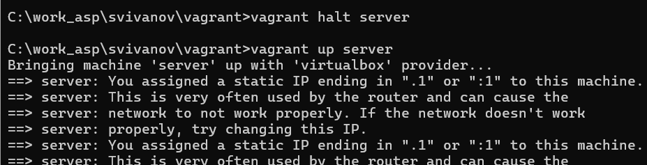

Запуск Server

## Настройка сервера сетевого журнала

На сервере создадим файл конфигурации сетевого хранения журналов:

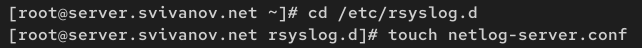

Создание конф. файла

## Настройка сервера сетевого журнала

Перезапустим службу rsyslog и посмотрим, какие порты, связанные с rsyslog, прослушиваются:

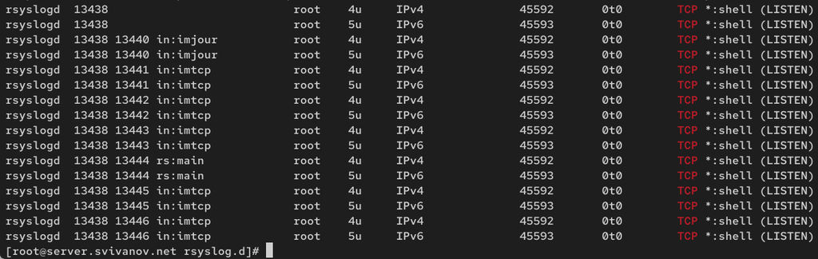

Просмотр портов связанных с rsyslog

## Настройка сервера сетевого журнала

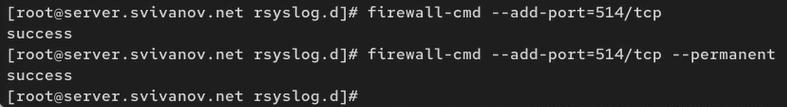

Настройка firewall

## Настройка клиента сетевого журнала

Запускаю виртуальную машину Client. (рис. 6)

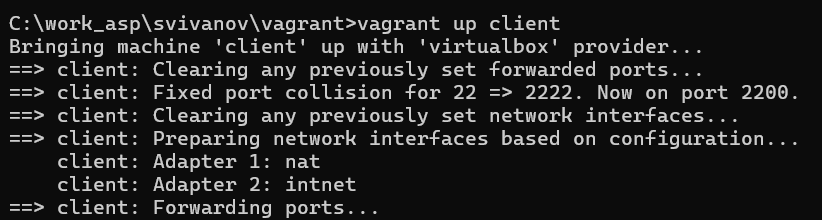

Запуск Client

## Настройка клиента сетевого журнала

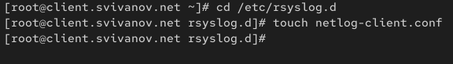

Создание конф.файла

## Настройка клиента сетевого журнала

На клиенте в файле конфигурации включим перенаправление сообщений на 514 сервера:

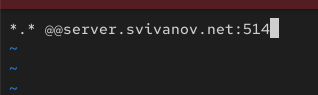

Редактирование конф. файла

## Настройка клиента сетевого журнала

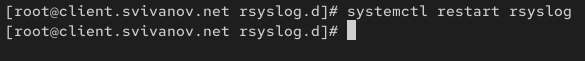

Перезапуск службы

## Просмотр журнала

На сервере просмотрим один из файлов журнала

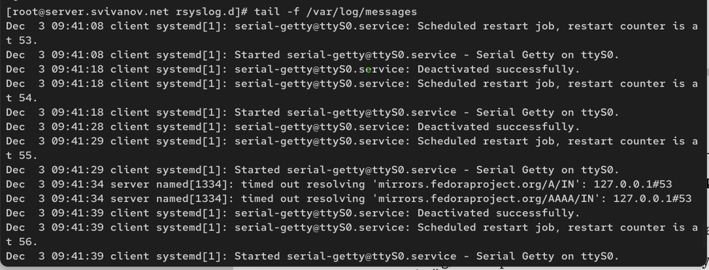

Просмотр файла журнала

## Просмотр журнала

[figure not shown]

## Просмотр журнала

На сервере установим просмотрщик журналов системных сообщений lnav:

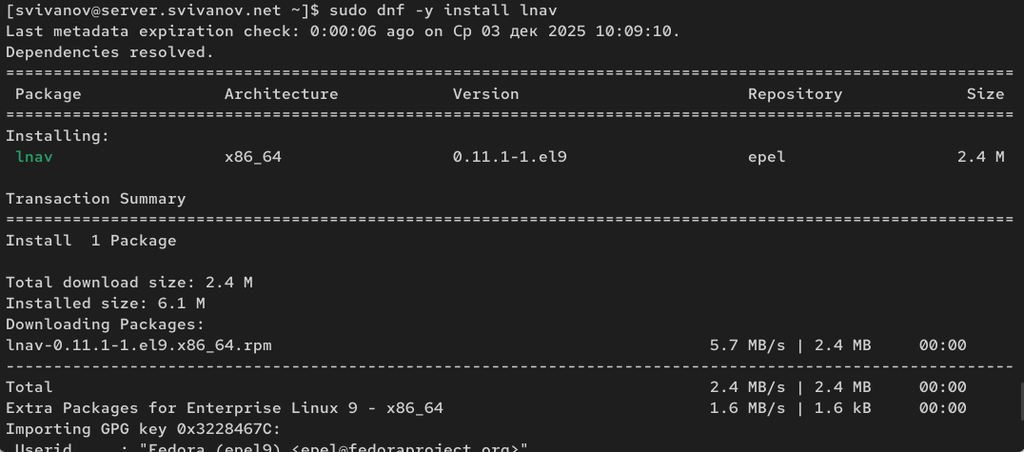

Установка lnav

## Просмотр журнала

Просмотр логов с помощью lnav на сервере:

[figure not shown]

Просмотр логов

## Просмотр журнала

На клиенте установим просмотрщик журналов системных сообщений lnav:

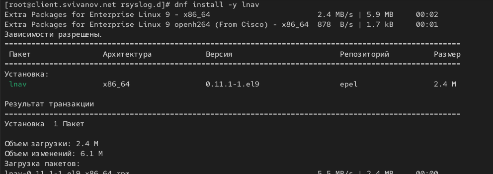

Установка lnav

## Просмотр журнала

Просмотр логов с помощью lnav на клиенте: (рис. 15)

[figure not shown]

Просмотр логов

## Внесение изменений в настройки внутреннего окружения виртуальных машин

На машине server перейдем в каталог для внесения изменений, в который поместим конфигурационные файлы:

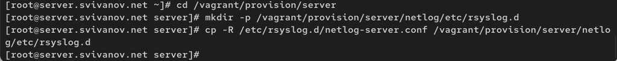

Создание каталогов и копирование конф.файлов

## Внесение изменений в настройки внутреннего окружения виртуальных машин

Создадм скрипт

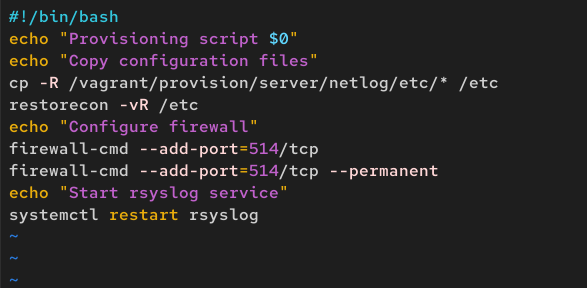

Создание скрипта

## Внесение изменений в настройки внутреннего окружения виртуальных машин

На машине client перейдем в каталог для внесения изменений, в который поместим конфигурационные файлы:

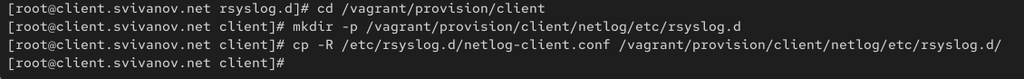

Создание каталогов и копирование конф.файлов

## Внесение изменений в настройки внутреннего окружения виртуальных машин

Создадм скрипт

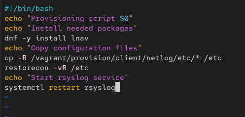

Создание скрипта

## Внесение изменений в настройки внутреннего окружения виртуальных машин

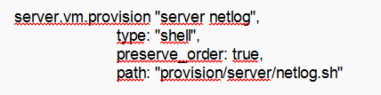

Редактирование Vagrantfile

## Внесение изменений в настройки внутреннего окружения виртуальных машин

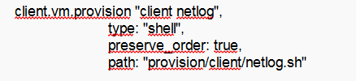

Редактирование Vagrantfile

## Вывод

В ходе выполнения лабораторной работы мы получили навыки по работе с журналами системных событий.